# Joint Testing of Mortality & Worst-rank score

민태원, 권대영

2023-01-13

## 1. Data

### 1.1 Preprocess (Dividing group A, B, C)

```r
final_r <- read.csv("data_final_death.csv")
data_set = final_r[, -c(1, 12, 14)]
str(data_set)
```

```
## 'data.frame':    7731 obs. of  20 variables:
##  $ gender         : int  0 0 1 0 1 1 0 1 0 0 ...
##  $ bmi            : int  1 0 0 0 0 0 0 0 0 0 ...
##  $ education      : int  0 1 1 0 1 0 0 0 0 0 ...
##  $ age            : int  81 59 60 78 79 72 68 75 70 63 ...
##  $ exercise       : int  0 0 0 0 1 1 0 0 0 0 ...
##  $ income         : int  1 1 1 0 0 0 0 1 1 0 ...
##  $ smoke          : int  0 0 0 0 0 0 0 1 0 0 ...
##  $ alcohol        : int  0 0 1 0 1 1 1 1 0 0 ...
##  $ chronic_disease: int  1 1 1 1 1 1 1 0 0 1 ...
##  $ treatment      : int  0 0 0 1 0 0 0 1 1 1 ...
##  $ job            : int  0 0 1 0 0 0 0 0 0 0 ...
##  $ region1        : int  1 1 1 1 1 1 1 1 1 1 ...
##  $ region2        : int  0 0 0 0 0 0 0 0 0 0 ...
##  $ depress5       : int  14 16 16 22 17 14 15 16 17 19 ...
##  $ depress6       : int  15 17 16 17 16 15 16 26 20 20 ...
##  $ depress7       : int  18 15 13 17 15 19 13 23 17 19 ...
##  $ depress8       : int  22 18 14 18 17 15 16 NA 14 17 ...
##  $ dead6          : int  0 0 0 0 0 0 0 0 0 0 ...
##  $ dead7          : int  0 0 0 0 0 0 0 0 0 0 ...
##  $ dead8          : int  0 0 0 0 0 0 0 1 0 0 ...
```

- covariates: `gender`, `bmi`, `education`, `exercise`, `income`, `smoke`, `alcohol`, `chronic_disease`, `job`, `region1`, `region2`, `age`, `depress5`
- outcome: `depress6`, `depress7`, `depress8`
- number of NAs by variable

```r
colSums(is.na(data_set))
```

```
##          gender             bmi       education             age        exercise
##               0               0               0               0               0
##          income           smoke         alcohol chronic_disease       treatment
##               0               0               0               0               0
##             job         region1         region2        depress5        depress6
##               0               0               0               0             555
##        depress7        depress8           dead6           dead7           dead8
##            1123            1566             204             389             617
```

- 1604 treatment, 6127 control

```r
table(data_set$treatment)
```

```
##
##    0    1
## 6127 1604
```

- Histogram for `age` (decrease due to death)

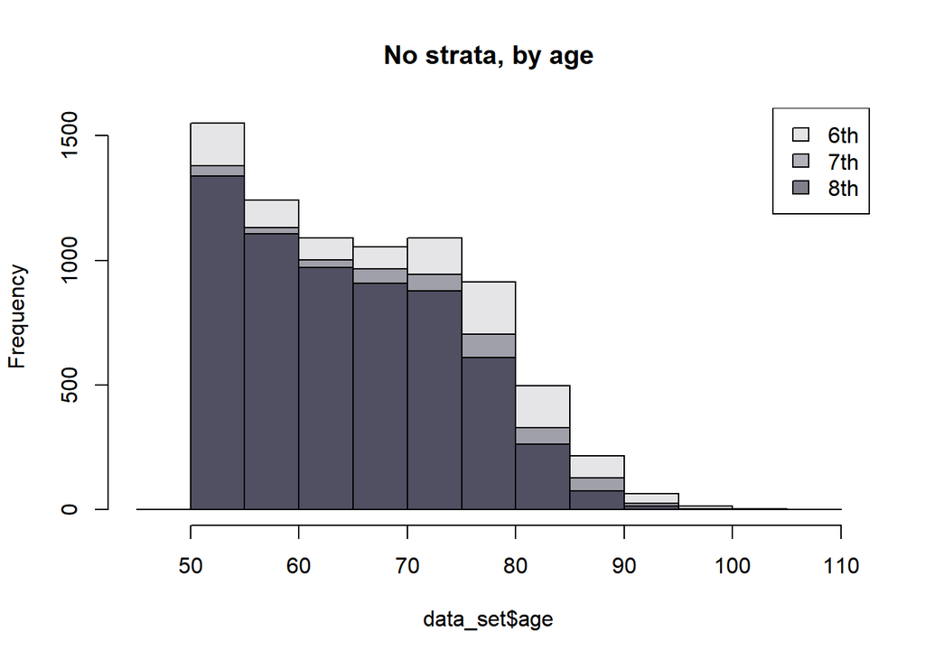

```r
hist1 = hist(data_set$age, freq = T, main = "No strata, by age", breaks = seq(45,110,5), col = rgb(0,0,0.1,0.1))
hist(data_set$age[!is.na(data_set$depress7)], freq = T, main = "No strata, by age, at 7th study", breaks = seq(50,100,5), add = T, col = rgb(0,0,0.1,0.3))
hist(data_set$age[!is.na(data_set$depress8)], freq = T, main = "No strata, by age, at 8th study", breaks = seq(50,100,5), add = T, col = rgb(0,0,0.1,0.5))
legend("topright", c("6th", "7th", "8th"), fill=c(rgb(0,0,0.1,0.1), rgb(0,0,0.1,0.3), rgb(0,0,0.1,0.5)) )
```

- Numbers of NAs in each study

```r
table(data_set$dead6, data_set$depress6 >= 0, useNA = "always")
```

```
##
##        TRUE <NA>
##   0    7176   87
##   1       0  264
##   <NA>    0  204
```

```r
table(data_set$dead7, data_set$depress7 >= 0, useNA = "always")
```

```
##
##        TRUE <NA>
##   0    6608  142
##   1       0  592
##   <NA>    0  389
```

```r
table(data_set$dead8, data_set$depress8 >= 0, useNA = "always")
```

```
##
##        TRUE <NA>
##   0    6165    0
##   1       0  949
##   <NA>    0  617
```

- `dead6` = 0, `depress6` = NA인 경우는 죽지 않았음이 확실하나(7차 혹은 8차의 outcome이 존재), 이번 조사에 참여하지 않은 집단(87명) $\rightarrow$ A
- `dead6` = 1 이고, `depress6` = NA인 집단은 확실히 사망한 집단 (264명) $\rightarrow$ B
- `dead6` = NA 인 경우, 6차 조사에 참여하지 않았으며, 이가 사망으로 인한 것인지 혹은 미참여인지 불분명한 집단 (204명) $\rightarrow$ C

### 1.2 각 집단의 비율 관찰 (너무 한쪽에 쏠려있지 않은지)

- A의 비율 관찰

```r
table(data_set$treatment, data_set$dead6==0 & is.na(data_set$depress6))
```

```
##
##     FALSE TRUE
##   0  5902   66
##   1  1538   21
```

```r
chisq.test(table(data_set$treatment, data_set$dead6==0 & is.na(data_set$depress6)))$p.value
```

```
## [1] 0.5092154
```

```r
table(data_set$treatment, data_set$dead7==0 & is.na(data_set$depress7))
```

```
##
##     FALSE TRUE
##   0  5699  110
##   1  1501   32
```

```r
chisq.test(table(data_set$treatment, data_set$dead7==0 & is.na(data_set$depress7)))$p.value
```

```
## [1] 0.6996209
```

```r
table(data_set$treatment, data_set$dead8==0 & is.na(data_set$depress8)) # No NA
```

```
##
##     FALSE
##   0  5622
##   1  1492
```

B는 worst-rank scoring에 포함시킬 것  
C는 MAR처리가 다소 불분명함. 우선은, 이를 MAR이라고 가정하고, 제거한 상태에서 분석을 실시하자. (가정 1)

- C의 비율 관찰

```r
table(data_set$treatment, is.na(data_set$dead6))
```

```
##
##     FALSE TRUE
##   0  5968  159
##   1  1559   45
```

```r
chisq.test(table(data_set$treatment, is.na(data_set$dead6)))$p.value
```

```
## [1] 0.7035293
```

```r
table(data_set$treatment, is.na(data_set$dead7))
```

```
##
##     FALSE TRUE
##   0  5809  318
##   1  1533   71
```

```r
chisq.test(table(data_set$treatment, is.na(data_set$dead7)))$p.value
```

```
## [1] 0.2374129
```

```r
table(data_set$treatment, is.na(data_set$dead8))
```

```
##
##     FALSE TRUE
##   0  5622  505
##   1  1492  112
```

```r
chisq.test(table(data_set$treatment, is.na(data_set$dead8)))$p.value
```

```
## [1] 0.1083744
```

마찬가지를 7차와 8차의 경우에도 실시할 수 있다.  
이 때, 7차와 8차는 점점 죽은 인원이 증가한다. 264 $\rightarrow$ 592 $\rightarrow$ 949명이다. 즉 매 차수마다 대략 3~400명 정도가 사망했음을 알 수 있다.  
worst-rank score를 부여할 때 5-6차 사이에 죽은 인원과 7-8차 사이에 죽은 인원의 score를 다르게 매긴다.

6차, 7차, 8차 조사가 모두 존재하는 집단 혹은, 6차, 7차, 8차 때 퇴출조사(사망)이 조사된 인원을 대상으로 매칭을 진행.

**우선, C(생사여부를 모름)만 제거한 채로 매칭시킨 뒤 death를 outcome으로 두고 대조군과 처리군을 비교한 뒤, 차이가 없으면 A를 추가로 제거하여 매칭시킨 뒤 worst rank test 진행**

## 2. Primary outcome (mortality)

```r
## 각 6, 7, 8차에서 C만 제거한 data_deleteC_6, data_deleteC_7, data_deleteC_8
data_deleteC_6 = data_set %>% filter(!is.na(dead6))
data_deleteC_7 = data_set %>% filter(!is.na(dead7))
data_deleteC_8 = data_set %>% filter(!is.na(dead8))
nrow(data_deleteC_6)
```

```
## [1] 7527
```

```r
nrow(data_deleteC_7)
```

```
## [1] 7342
```

```r
nrow(data_deleteC_8)
```

```
## [1] 7114
```

### 2.1 outcome = `dead6`

#### 2.1.1 Prepare the Data (PS, CBPS, RF, IPW/SIPW)

- Random Forest

```r
rf.6 <- randomForest(treatment~gender + bmi + education + age + exercise + income +
               smoke + alcohol + chronic_disease + job + region1 + region2 + depress5,
             data=data_deleteC_6, importance=T)
importance(rf.6, type=2)
```

- define depress5 group indices

```r
depress5_group = rep(0, length(data_deleteC_6$depress5))

depress5_group[which((data_deleteC_6$depress5 >=10 & data_deleteC_6$depress5 <= 14) == 1)] = 1
depress5_group[which((data_deleteC_6$depress5 >=15 & data_deleteC_6$depress5 <= 19) == 1)] = 2
depress5_group[which((data_deleteC_6$depress5 >=20 & data_deleteC_6$depress5 <= 24) == 1)] = 3
depress5_group[which((data_deleteC_6$depress5 >=25 & data_deleteC_6$depress5 <= 29) == 1)] = 4
depress5_group[which((data_deleteC_6$depress5 >=30 & data_deleteC_6$depress5 <= 34) == 1)] = 5
depress5_group[which((data_deleteC_6$depress5 >=35 & data_deleteC_6$depress5 <= 40) == 1)] = 6
table(data_deleteC_6$treatment, depress5_group, useNA = "always")
```

```
##       depress5_group
##           1    2    3    4    5    6 <NA>
##   0    1972 3090  647  158   55   46    0
##   1     250  624  397  189   64   35    0
##   <NA>    0    0    0    0    0    0    0
```

#### 2.1.2 Pair Matching

- Flip

```r
table(data_deleteC_6$treatment, depress5_group, useNA = "always")
```

```
##       depress5_group
##           1    2    3    4    5    6 <NA>
##   0    1972 3090  647  158   55   46    0
##   1     250  624  397  189   64   35    0
##   <NA>    0    0    0    0    0    0    0
```

- depress5 group 4, 5에 속하는 사람들이 treatment group에 더 많으므로 두 집단을 flip

```r
data_set_flip = data_deleteC_6

data_set_flip[depress5_group == 4 & data_deleteC_6$treatment ==1, ]$treatment = 0
data_set_flip[depress5_group == 4 & data_deleteC_6$treatment ==0, ]$treatment = 1
data_set_flip[depress5_group == 5 & data_deleteC_6$treatment ==1, ]$treatment = 0
data_set_flip[depress5_group == 5 & data_deleteC_6$treatment ==0, ]$treatment = 1

table(data_set_flip$treatment, depress5_group, useNA = "always")
```

```
##       depress5_group
##           1    2    3    4    5    6 <NA>
##   0    1972 3090  647  189   64   46    0
##   1     250  624  397  158   55   35    0
##   <NA>    0    0    0    0    0    0    0
```

- match the data

```r
# PS estimation
propensity.flip <- glm(treatment ~ gender + bmi + education + age + exercise + income + smoke + alcohol + chronic_disease + job + region1 + region2 + depress5, family = binomial, x = TRUE, data = data_set_flip)

# create rank Mahal distance matrix exactly for depress5
mah.dist.flip = match_on(treatment ~ gender + bmi + education + age + exercise + income + smoke + alcohol + chronic_disease + job + region1 + region2 + depress5,
                    within = exactMatch(data_set_flip$treatment ~ depress5_group), data = data_set_flip, method = "rank_mahalanobis")

# add caliper (if logit ps diff > 0.2*sd)
mah.dist.flip.caliper = addcaliper(mah.dist.flip, data_set_flip$treatment, predict(propensity.flip), calipersd = 0.2, penalty = 1000)
dimnames(mah.dist.flip.caliper) <- NULL

# add penalty (500 per age diff)
mah.dist.flip.caliper = addpenalty(mah.dist.flip.caliper, data_set_flip$treatment, data_set_flip$age, penalty = 500)

# pair matching
pairmatch.6 = matchit(treatment ~ gender + bmi + education + age + exercise + income + smoke + alcohol + chronic_disease + job + region1 + region2 + depress5, data = data_set_flip, method = "optimal", distance = as.matrix(mah.dist.flip.caliper), ratio = 1)

summary(pairmatch.6)$nn
```

```
##               Control Treated
## All (ESS)        6008    1519
## All              6008    1519
## Matched (ESS)    1519    1519
## Matched          1519    1519
## Unmatched        4489       0
## Discarded           0       0
```

- check covariate balance

```
##                 stand.diff.before stand.diff.after
## gender                     -0.430           -0.117
## bmi                         0.090            0.085
## education                  -0.706           -0.113
## age                         0.799            0.132
## exercise                   -0.273           -0.079
## income                     -0.495           -0.037
## smoke                      -0.180            0.039
## alcohol                    -0.438           -0.029
## chronic_disease             0.598            0.099
## job                        -0.501           -0.028
## region1                    -0.142           -0.062
## region2                    -0.067           -0.047
## depress5                    0.679            0.027
```

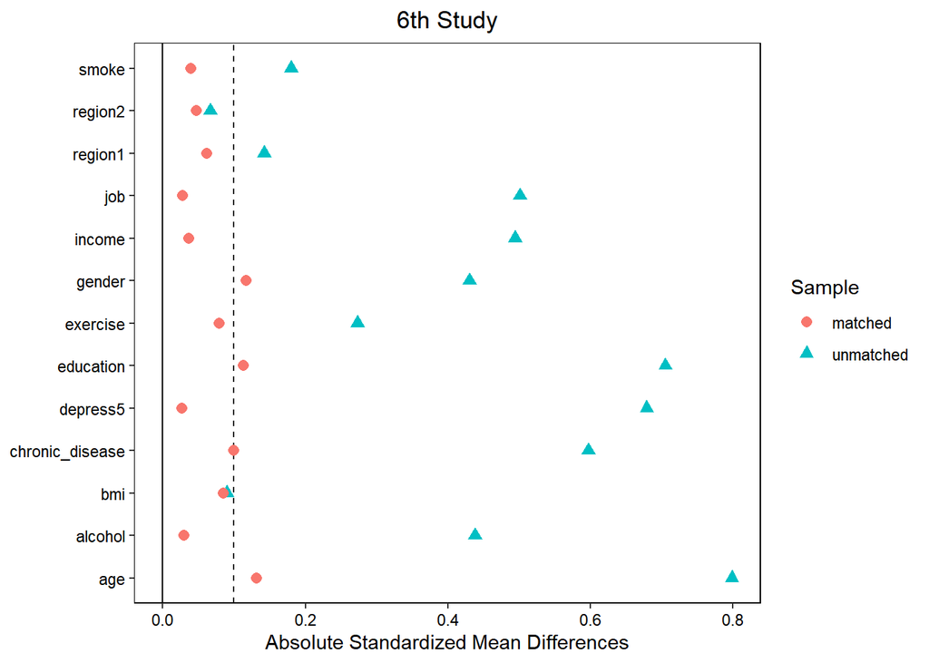

#### 2.1.3 test for mortality

```r
outcome6.treatment <- data_deleteC_6$dead6[treated.subject.index.6]
outcome6.matched.control<- data_deleteC_6$dead6[matched.control.subject.index.6]
outcome.table6 = table(outcome6.treatment, outcome6.matched.control)
outcome.table6
```

```
##                   outcome6.matched.control
## outcome6.treatment    0    1
##                  0 1349   65
##                  1   91   14
```

- Mcnemar test (two-sided)

```r
mcnemar.test(outcome.table6)$p.value / 2
```

```
## [1] 0.02266378
```

- Exact binomial test

```r
binom.test(c(outcome.table6[2,1], outcome.table6[1,2]), alternative="greater")$p.value
```

```
## [1] 0.02249008
```

#### 2.1.4 Sensitivity Analysis for McNemar’s test

```r
sens.analysis.mcnemar=function(D,Tobs,Gamma){
  p.positive = Gamma/(1+Gamma);
  p.negative = 1/(1+Gamma);
  lower.bound = 1-pbinom(Tobs-1,D,p.negative);
  upper.bound = 1-pbinom(Tobs-1,D,p.positive);

  exp.p.positive = p.positive*D #E()
  exp.p.negative = p.negative*D
  var.p.positive = p.positive*(1-p.positive)*D
  var.p.negative = p.negative*(1-p.negative)*D
  upper.bound.approx = 1 - pnorm((Tobs-exp.p.positive)/sqrt(var.p.positive))
  lower.bound.approx = 1 - pnorm((Tobs-exp.p.negative)/sqrt(var.p.negative))

  list(lower=lower.bound,upper=upper.bound,
       lower.appx = lower.bound.approx,
       upper.appx = upper.bound.approx);
}
```

- $\Gamma = 1.05$

```r
Gamma.grid = seq(1, 1.1, by=0.01)
lower.b = upper.b = rep(NA, length(Gamma.grid))

# 6th
for(i in 1:length(Gamma.grid)){
  sens.res = sens.analysis.mcnemar(D = 156, Tobs = 91, Gamma = Gamma.grid[i])
  lower.b[i] = sens.res$lower
  upper.b[i] = sens.res$upper
}
data.frame("Gamma"=Gamma.grid, "lower.b"=round(lower.b,4), "upper.b"=round(upper.b,4))
```

```
##    Gamma lower.b upper.b
## 1   1.00  0.0225  0.0225
## 2   1.01  0.0194  0.0260
## 3   1.02  0.0166  0.0300
## 4   1.03  0.0143  0.0344
## 5   1.04  0.0122  0.0392
## 6   1.05  0.0105  0.0445
## 7   1.06  0.0089  0.0504
## 8   1.07  0.0076  0.0567
## 9   1.08  0.0065  0.0637
## 10  1.09  0.0055  0.0711
## 11  1.10  0.0047  0.0792
```

```r
(Gamma.6.death = Gamma.grid[max(which(upper.b < 0.05))])
```

```
## [1] 1.05
```

### 2.2 outcome = `dead7`

#### 2.2.1 Prepare the Data (PS, CBPS, RF, IPW/SIPW)

- Random Forest

```r
rf.7 <- randomForest(treatment~gender + bmi + education + age + exercise + income +
               smoke + alcohol + chronic_disease + job + region1 + region2 + depress5,
             data=data_deleteC_7, importance=T)
importance(rf.7, type=2)
```

- define depress5 group indices

```r
depress5_group = rep(0, length(data_deleteC_7$depress5))

depress5_group[which((data_deleteC_7$depress5 >=10 & data_deleteC_7$depress5 <= 14) == 1)] = 1
depress5_group[which((data_deleteC_7$depress5 >=15 & data_deleteC_7$depress5 <= 19) == 1)] = 2
depress5_group[which((data_deleteC_7$depress5 >=20 & data_deleteC_7$depress5 <= 24) == 1)] = 3
depress5_group[which((data_deleteC_7$depress5 >=25 & data_deleteC_7$depress5 <= 29) == 1)] = 4
depress5_group[which((data_deleteC_7$depress5 >=30 & data_deleteC_7$depress5 <= 34) == 1)] = 5
depress5_group[which((data_deleteC_7$depress5 >=35 & data_deleteC_7$depress5 <= 40) == 1)] = 6
table(data_deleteC_7$treatment, depress5_group, useNA = "always")
```

```
##       depress5_group
##           1    2    3    4    5    6 <NA>
##   0    1928 2991  636  153   54   47    0
##   1     243  620  382  185   68   35    0
##   <NA>    0    0    0    0    0    0    0
```

#### 2.2.2 Pair Matching

- Flip

```r
table(data_deleteC_7$treatment, depress5_group, useNA = "always")
```

```
##       depress5_group
##           1    2    3    4    5    6 <NA>
##   0    1928 2991  636  153   54   47    0
##   1     243  620  382  185   68   35    0
##   <NA>    0    0    0    0    0    0    0
```

- depress5 group 4, 5에 속하는 사람들이 treatment group에 더 많으므로 두 집단을 flip

```r
data_set_flip = data_deleteC_7

data_set_flip[depress5_group == 4 & data_deleteC_7$treatment ==1, ]$treatment = 0
data_set_flip[depress5_group == 4 & data_deleteC_7$treatment ==0, ]$treatment = 1
data_set_flip[depress5_group == 5 & data_deleteC_7$treatment ==1, ]$treatment = 0
data_set_flip[depress5_group == 5 & data_deleteC_7$treatment ==0, ]$treatment = 1

table(data_set_flip$treatment, depress5_group, useNA = "always")
```

```
##       depress5_group
##           1    2    3    4    5    6 <NA>
##   0    1928 2991  636  185   68   47    0
##   1     243  620  382  153   54   35    0
##   <NA>    0    0    0    0    0    0    0
```

- match the data

```r
# PS estimation
propensity.flip <- glm(treatment ~ gender + bmi + education + age + exercise + income + smoke + alcohol + chronic_disease + job + region1 + region2 + depress5, family = binomial, x = TRUE, data = data_set_flip)

# create rank Mahal distance matrix exactly for depress5
mah.dist.flip = match_on(treatment ~ gender + bmi + education + age + exercise + income + smoke + alcohol + chronic_disease + job + region1 + region2 + depress5,
                    within = exactMatch(data_set_flip$treatment ~ depress5_group), data = data_set_flip, method = "rank_mahalanobis")

# add caliper (if logit ps diff > 0.2*sd)
mah.dist.flip.caliper = addcaliper(mah.dist.flip, data_set_flip$treatment, predict(propensity.flip), calipersd = 0.2, penalty = 1000)
dimnames(mah.dist.flip.caliper) <- NULL

# add penalty (500 per age diff)
mah.dist.flip.caliper = addpenalty(mah.dist.flip.caliper, data_set_flip$treatment, data_set_flip$age, penalty = 500)

# pair matching
pairmatch.7 = matchit(treatment ~ gender + bmi + education + age + exercise + income + smoke + alcohol + chronic_disease + job + region1 + region2 + depress5, data = data_set_flip, method = "optimal", distance = as.matrix(mah.dist.flip.caliper), ratio = 1)

summary(pairmatch.7)$nn
```

```
##               Control Treated
## All (ESS)        5855    1487
## All              5855    1487
## Matched (ESS)    1487    1487
## Matched          1487    1487
## Unmatched        4368       0
## Discarded           0       0
```

- get matched set index

```
##                 stand.diff.before stand.diff.after
## gender                     -0.434           -0.119
## bmi                         0.094            0.091
## education                  -0.703           -0.108
## age                         0.794            0.117
## exercise                   -0.271           -0.079
## income                     -0.488           -0.038
## smoke                      -0.172            0.040
## alcohol                    -0.428           -0.044
## chronic_disease             0.598            0.091
## job                        -0.495           -0.029
## region1                    -0.146           -0.056
## region2                    -0.057           -0.035
## depress5                    0.680            0.023
```

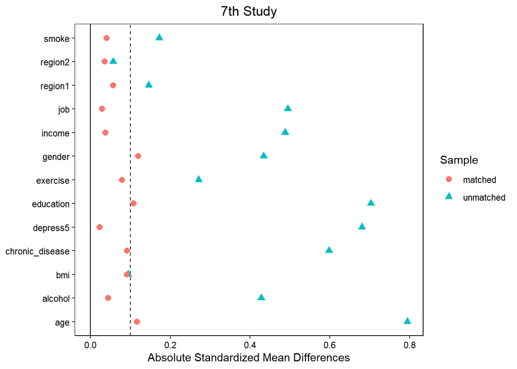

#### 2.2.3 Test for mortality

```r
outcome7.treatment <- data_deleteC_7$dead7[treated.subject.index.7]
outcome7.matched.control<- data_deleteC_7$dead7[matched.control.subject.index.7]
outcome.table7 = table(outcome7.treatment, outcome7.matched.control)
outcome.table7
```

```
##                   outcome7.matched.control
## outcome7.treatment    0    1
##                  0 1139  144
##                  1  158   46
```

- Mcnemar test (two-sided)

```r
mcnemar.test(outcome.table7)$p.value / 2
```

```
## [1] 0.2272102
```

- Exact binomial test

```r
binom.test(c(outcome.table7[2,1], outcome.table7[1,2]), alternative="greater")$p.value
```

```
## [1] 0.2272379
```

### 2.3 outcome = `dead8`

#### 2.3.1 Prepare the Data (PS, CBPS, RF, IPW/SIPW)

- Random Forest

```r
rf.8 <- randomForest(treatment~gender + bmi + education + age + exercise + income +
               smoke + alcohol + chronic_disease + job + region1 + region2 + depress5,
             data=data_deleteC_8, importance=T)
importance(rf.8, type=2)
```

- define depress5 group indices

```r
depress5_group = rep(0, length(data_deleteC_8$depress5))

depress5_group[which((data_deleteC_8$depress5 >=10 & data_deleteC_8$depress5 <= 14) == 1)] = 1
depress5_group[which((data_deleteC_8$depress5 >=15 & data_deleteC_8$depress5 <= 19) == 1)] = 2
depress5_group[which((data_deleteC_8$depress5 >=20 & data_deleteC_8$depress5 <= 24) == 1)] = 3
depress5_group[which((data_deleteC_8$depress5 >=25 & data_deleteC_8$depress5 <= 29) == 1)] = 4
depress5_group[which((data_deleteC_8$depress5 >=30 & data_deleteC_8$depress5 <= 34) == 1)] = 5
depress5_group[which((data_deleteC_8$depress5 >=35 & data_deleteC_8$depress5 <= 40) == 1)] = 6
```

#### 2.3.2 Pair Matching

- Flip

```r
table(data_deleteC_8$treatment, depress5_group, useNA = "always")
```

```
##       depress5_group
##           1    2    3    4    5    6 <NA>
##   0    1869 2890  617  152   54   40    0
##   1     242  599  371  178   67   35    0
##   <NA>    0    0    0    0    0    0    0
```

- depress5 group 4, 5에 속하는 사람들이 treatment group에 더 많으므로 두 집단을 flip

```r
data_set_flip = data_deleteC_8

data_set_flip[depress5_group == 4 & data_deleteC_8$treatment ==1, ]$treatment = 0
data_set_flip[depress5_group == 4 & data_deleteC_8$treatment ==0, ]$treatment = 1
data_set_flip[depress5_group == 5 & data_deleteC_8$treatment ==1, ]$treatment = 0
data_set_flip[depress5_group == 5 & data_deleteC_8$treatment ==0, ]$treatment = 1

table(data_set_flip$treatment, depress5_group, useNA = "always")
```

```
##       depress5_group
##           1    2    3    4    5    6 <NA>
##   0    1869 2890  617  178   67   40    0
##   1     242  599  371  152   54   35    0
##   <NA>    0    0    0    0    0    0    0
```

- match the data

```r
# PS estimation
propensity.flip <- glm(treatment ~ gender + bmi + education + age + exercise + income + smoke + alcohol + chronic_disease + job + region1 + region2 + depress5, family = binomial, x = TRUE, data = data_set_flip)

# create rank Mahal distance matrix exactly for depress5
mah.dist.flip = match_on(treatment ~ gender + bmi + education + age + exercise + income + smoke + alcohol + chronic_disease + job + region1 + region2 + depress5,
                    within = exactMatch(data_set_flip$treatment ~ depress5_group), data = data_set_flip, method = "rank_mahalanobis")

# add caliper (if logit ps diff > 0.2*sd)
mah.dist.flip.caliper = addcaliper(mah.dist.flip, data_set_flip$treatment, predict(propensity.flip), calipersd = 0.2, penalty = 1000)
dimnames(mah.dist.flip.caliper) <- NULL

# add penalty (500 per age diff)
mah.dist.flip.caliper = addpenalty(mah.dist.flip.caliper, data_set_flip$treatment, data_set_flip$age, penalty = 500)

# pair matching
pairmatch.8 = matchit(treatment ~ gender + bmi + education + age + exercise + income + smoke + alcohol + chronic_disease + job + region1 + region2 + depress5, data = data_set_flip, method = "optimal", distance = as.matrix(mah.dist.flip.caliper), ratio = 1)

summary(pairmatch.8)$nn
```

```
##               Control Treated
## All (ESS)        5661    1453
## All              5661    1453
## Matched (ESS)    1453    1453
## Matched          1453    1453
## Unmatched        4208       0
## Discarded           0       0
```

- get matched set index

```
##                 stand.diff.before stand.diff.after
## gender                     -0.433           -0.112
## bmi                         0.086            0.089
## education                  -0.699           -0.107
## age                         0.789            0.115
## exercise                   -0.270           -0.077
## income                     -0.479           -0.043
## smoke                      -0.172            0.047
## alcohol                    -0.426           -0.038
## chronic_disease             0.592            0.104
## job                        -0.493           -0.035
## region1                    -0.150           -0.056
## region2                    -0.052           -0.037
## depress5                    0.679            0.022
```

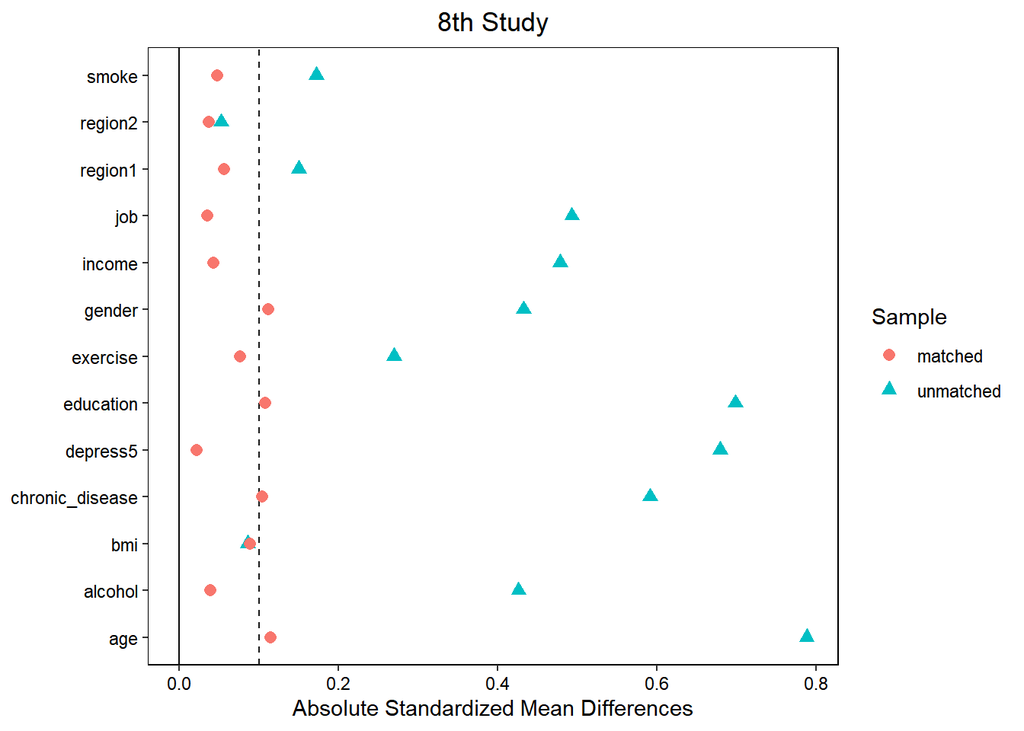

#### 2.3.3 Test for mortality

```r
outcome8.treatment <- data_deleteC_8$dead8[treated.subject.index.8]
outcome8.matched.control<- data_deleteC_8$dead8[matched.control.subject.index.8]
outcome.table8 = table(outcome8.treatment, outcome8.matched.control)
outcome.table8
```

```
##                   outcome8.matched.control
## outcome8.treatment   0   1
##                  0 946 180
##                  1 206 121
```

- Mcnemar test (two-sided)

```r
mcnemar.test(outcome.table8)$p.value / 2
```

```
## [1] 0.1016037
```

- Exact binomial test

```r
binom.test(c(outcome.table8[2,1], outcome.table8[1,2]), alternative="greater")$p.value
```

```
## [1] 0.1015736
```

## 3. Worst-rank score (mortality + depress)

### 3.1 전처리

```r
##A와 C사라지는 코드
data_set_cleaned = data_set %>% filter((!is.na(depress8) & !is.na(depress7) & !is.na(depress6)) | dead8 == 1)
nrow(data_set_cleaned)
```

```
## [1] 6927
```

```r
## worst-rank 부여
data_set_cleaned$depress8[data_set_cleaned$dead8 == 1] <- 1000
data_set_cleaned$depress7[data_set_cleaned$dead7 == 1] <- 1000.1
data_set_cleaned$depress8[data_set_cleaned$dead7 == 1] <- 1000.1
data_set_cleaned$depress6[data_set_cleaned$dead6 == 1] <- 1000.2
data_set_cleaned$depress7[data_set_cleaned$dead6 == 1] <- 1000.2
data_set_cleaned$depress8[data_set_cleaned$dead6 == 1] <- 1000.2

## 6차와 7차에서는 depress 척도가 NA인 경우가 존재한다. -> 6차의 예시로, 7 혹은 8차 때 사망했고,  6차 때 미조사된 인원.
## 이런 인원들 제거한다.
table(data_set_cleaned$treatment, data_set_cleaned$depress6, useNA = "always")
```

```
##
##          10   11   12   13   14   15   16   17   18   19   20   21   22   23
##   0     568   70  251  269  531  422 1438  427  266  210  167  120  127   80
##   1      70    9   51   54   96   70  206   96   80   72   92   72   51   54
##   <NA>    0    0    0    0    0    0    0    0    0    0    0    0    0    0
##
##          24   25   26   27   28   29   30   31   32   33   34   35   36   37
##   0      86   70   52   42   21   20   17   13    9    8    5    1    2    1
##   1      41   39   40   20   31   20   15   16    7    7    4    3    1    0
##   <NA>    0    0    0    0    0    0    0    0    0    0    0    0    0    0
##
##          38 1000.2 <NA>
##   0       1    149   35
##   1       0    115   17
##   <NA>    0      0    0
```

```r
data_set_cleaned = data_set_cleaned %>% filter((!is.na(depress8) & !is.na(depress7) & !is.na(depress6)))
table(data_set_cleaned$treatment, data_set_cleaned$depress6, useNA = "always")
```

```
##
##          10   11   12   13   14   15   16   17   18   19   20   21   22   23
##   0     564   69  250  267  531  420 1432  423  262  206  166  119  127   80
##   1      70    9   50   54   96   68  206   94   79   71   91   72   49   53
##   <NA>    0    0    0    0    0    0    0    0    0    0    0    0    0    0
##
##          24   25   26   27   28   29   30   31   32   33   34   35   36   37
##   0      84   69   52   41   21   20   17   12    9    8    5    1    2    1
##   1      40   38   40   20   30   20   15   15    6    7    4    3    1    0
##   <NA>    0    0    0    0    0    0    0    0    0    0    0    0    0    0
##
##          38 1000.2 <NA>
##   0       1    149    0
##   1       0    115    0
##   <NA>    0      0    0
```

```r
table(data_set_cleaned$dead6, data_set_cleaned$depress6 >= 0, useNA = "always")
```

```
##
##        TRUE <NA>
##   0    6560    0
##   1     264    0
##   <NA>    0    0
```

```r
table(data_set_cleaned$dead7, data_set_cleaned$depress7 >= 0, useNA = "always")
```

```
##
##        TRUE <NA>
##   0    6263    0
##   1     561    0
##   <NA>    0    0
```

```r
table(data_set_cleaned$dead8, data_set_cleaned$depress8 >= 0, useNA = "always")
```

```
##
##        TRUE <NA>
##   0    5978    0
##   1     846    0
##   <NA>    0    0
```

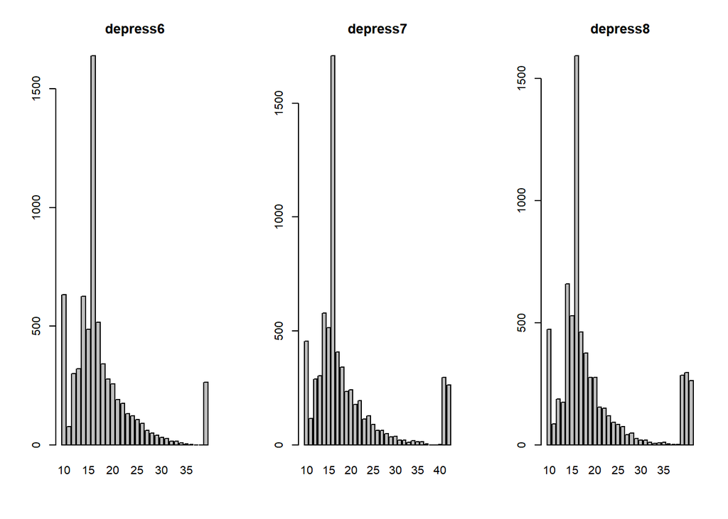

```r
par(mfrow = c(1,3))
barplot(table(data_set_cleaned$depress6), main = "depress6")
barplot(table(data_set_cleaned$depress7), main = "depress7")
barplot(table(data_set_cleaned$depress8), main = "depress8")
```

6차때 사망한 인원은 1000.2, 7차 때 사망한 인원은 1000.1, 8차 때 사망한 인원은 1000의 score를 부여했다.  
총 표본은 6824 명으로, 기존 데이터의 총 표본은 7731명이었다. NA들이 대략 900명 빠진 상황이다.  
data_set_cleaned에는 depress6/7/8에 NA가 존재하지 않는다. 10~40, 1000, 1000.1, 1000.2의 범위를 지닌다.

- define depress5 group indices

```r
depress5_group = rep(0, length(data_set_cleaned$depress5))

depress5_group[which((data_set_cleaned$depress5 >=10 & data_set_cleaned$depress5 <= 14) == 1)] = 1
depress5_group[which((data_set_cleaned$depress5 >=15 & data_set_cleaned$depress5 <= 19) == 1)] = 2
depress5_group[which((data_set_cleaned$depress5 >=20 & data_set_cleaned$depress5 <= 24) == 1)] = 3
depress5_group[which((data_set_cleaned$depress5 >=25 & data_set_cleaned$depress5 <= 29) == 1)] = 4
depress5_group[which((data_set_cleaned$depress5 >=30 & data_set_cleaned$depress5 <= 34) == 1)] = 5
depress5_group[which((data_set_cleaned$depress5 >=35 & data_set_cleaned$depress5 <= 40) == 1)] = 6
table(data_set_cleaned$treatment, depress5_group, useNA = "always")
```

```
##       depress5_group
##           1    2    3    4    5    6 <NA>
##   0    1818 2763  594  148   48   37    0
##   1     230  580  345  167   61   33    0
##   <NA>    0    0    0    0    0    0    0
```

- Propensity Score estimation

```r
propensity <- glm(treatment ~ gender + bmi + education + age + exercise + income + smoke + alcohol + chronic_disease + job + region1 + region2 + depress5, family = binomial, x = TRUE, data = data_set_cleaned)
propensity_logit <- predict(propensity)
propensity_score <- predict(propensity,type = "response")
```

- Random Forest

```r
rf <- randomForest(treatment~gender + bmi + education + age + exercise + income +
               smoke + alcohol + chronic_disease + job + region1 + region2 + depress5,
             data=data_set_cleaned, importance=T)
importance(rf, type=2)
```

### 3.2 Pair Matching

#### 3.2.1 Flip

```r
depress5_group = rep(0, length(data_set_cleaned$depress5))

depress5_group[which((data_set_cleaned$depress5 >=10 & data_set_cleaned$depress5 <= 14) == 1)] = 1
depress5_group[which((data_set_cleaned$depress5 >=15 & data_set_cleaned$depress5 <= 19) == 1)] = 2
depress5_group[which((data_set_cleaned$depress5 >=20 & data_set_cleaned$depress5 <= 24) == 1)] = 3
depress5_group[which((data_set_cleaned$depress5 >=25 & data_set_cleaned$depress5 <= 29) == 1)] = 4
depress5_group[which((data_set_cleaned$depress5 >=30 & data_set_cleaned$depress5 <= 34) == 1)] = 5
depress5_group[which((data_set_cleaned$depress5 >=35 & data_set_cleaned$depress5 <= 40) == 1)] = 6
table(data_set_cleaned$treatment, depress5_group, useNA = "always")
```

```
##       depress5_group
##           1    2    3    4    5    6 <NA>
##   0    1818 2763  594  148   48   37    0
##   1     230  580  345  167   61   33    0
##   <NA>    0    0    0    0    0    0    0
```

```r
data_set_flip = data_set_cleaned

data_set_flip[depress5_group == 4 & data_set_cleaned$treatment ==1, ]$treatment = 0
data_set_flip[depress5_group == 4 & data_set_cleaned$treatment ==0, ]$treatment = 1
data_set_flip[depress5_group == 5 & data_set_cleaned$treatment ==1, ]$treatment = 0
data_set_flip[depress5_group == 5 & data_set_cleaned$treatment ==0, ]$treatment = 1

table(data_set_flip$treatment, depress5_group, useNA = "always")
```

```
##       depress5_group
##           1    2    3    4    5    6 <NA>
##   0    1818 2763  594  167   61   37    0
##   1     230  580  345  148   48   33    0
##   <NA>    0    0    0    0    0    0    0
```

#### 3.2.2 match the data

```r
propensity.flip <- glm(treatment ~ gender + bmi + education + age + exercise + income + smoke + alcohol + chronic_disease + job + region1 + region2 + depress5, family = binomial, x = TRUE, data = data_set_flip)

mah.dist.flip = match_on(treatment ~ gender + bmi + education + age + exercise + income + smoke + alcohol + chronic_disease + job + region1 + region2 + depress5,
                    within = exactMatch(data_set_flip$treatment ~ depress5_group), data = data_set_flip, method = "rank_mahalanobis")

mah.dist.flip.caliper = addcaliper(mah.dist.flip, data_set_flip$treatment, predict(propensity.flip), calipersd = 0.2, penalty = 1000)
dimnames(mah.dist.flip.caliper) <- NULL

mah.dist.flip.caliper = addpenalty(mah.dist.flip.caliper, data_set_flip$treatment, data_set_flip$age, penalty = 30)

pairmatch = matchit(treatment ~ gender + bmi + education + age + exercise + income + smoke + alcohol + chronic_disease + job + region1 + region2 + depress5, data = data_set_flip, method = "optimal", distance = as.matrix(mah.dist.flip.caliper), ratio = 1)

summary(pairmatch)$nn
```

```
##               Control Treated
## All (ESS)        5440    1384
## All              5440    1384
## Matched (ESS)    1384    1384
## Matched          1384    1384
## Unmatched        4056       0
## Discarded           0       0
```

#### 3.2.3 get matched set index

```
## [1] 1384
```

```
## [1] 1384
```

#### 3.2.4 check covariate balance

```
##                 stand.diff.before stand.diff.after
## gender                -0.41836152      -0.09127660
## bmi                    0.08925604       0.05591681
## education             -0.68524989      -0.08841643
## age                    0.77307718       0.13656045
## exercise              -0.26744262      -0.05954203
## income                -0.46443223      -0.04922154
## smoke                 -0.16786960       0.05583840
## alcohol               -0.41540599      -0.03694527
## chronic_disease        0.58469418       0.09127459
## job                   -0.48016089      -0.02306527
## region1               -0.16078448      -0.05758926
## region2               -0.03798930      -0.02487972
## depress5               0.67232402       0.02001621
```

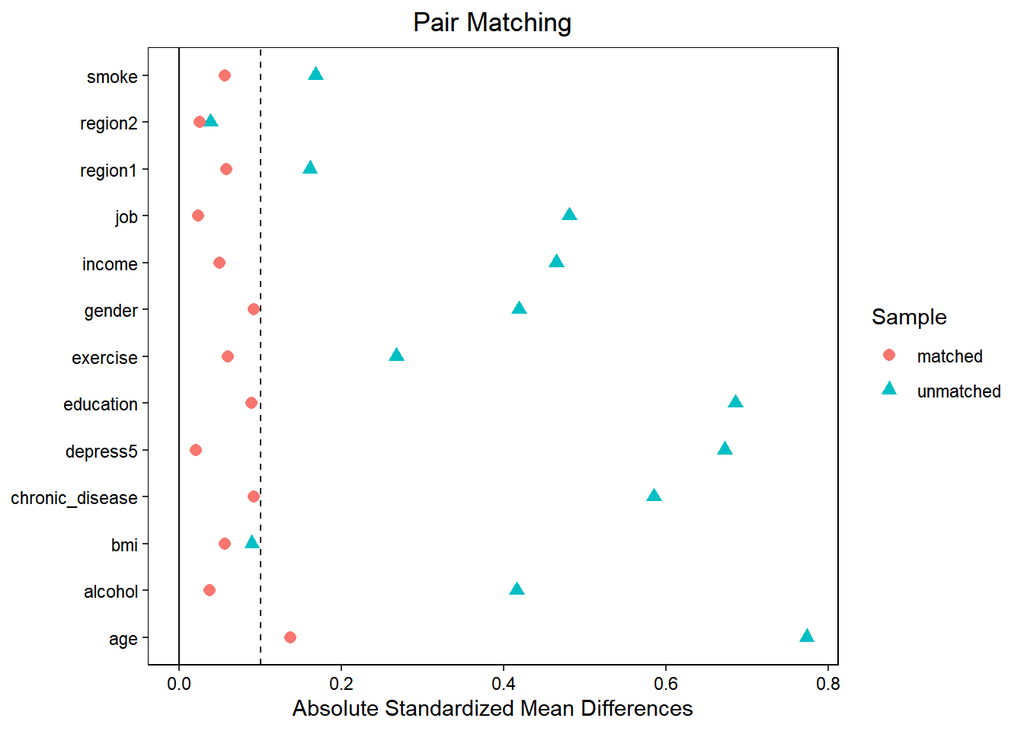

```r
smd0 <- cbind(stand.diff.before, stand.diff.after)
SMDplot(Xmat, abs(smd0), names=c("unmatched", "matched"), title="Pair Matching")
```

#### 3.2.5 Wilcoxon’s signed rank test

```r
outcome6.treatment <- data_set_cleaned$depress6[treated.subject.index]
outcome6.matched.control<- data_set_cleaned$depress6[matched.control.subject.index]

outcome7.treatment <- data_set_cleaned$depress7[treated.subject.index]
outcome7.matched.control<- data_set_cleaned$depress7[matched.control.subject.index]

outcome8.treatment <- data_set_cleaned$depress8[treated.subject.index]
outcome8.matched.control<- data_set_cleaned$depress8[matched.control.subject.index]

# Wilcoxon signed rank test
pval6 = wilcox.test(outcome6.treatment,outcome6.matched.control,paired=TRUE,conf.int=TRUE)$p.value
pval7 = wilcox.test(outcome7.treatment,outcome7.matched.control,paired=TRUE,conf.int=TRUE)$p.value
pval8 = wilcox.test(outcome8.treatment,outcome8.matched.control,paired=TRUE,conf.int=TRUE)$p.value

c("6th"=pval6, "7th"=pval7, "8th"=pval8)
```

```
##          6th          7th          8th
## 5.320339e-06 2.861164e-04 2.220976e-07
```

#### 3.2.6 Sensitivity Analysis

```r
sens.analysis.signedrank=function(diff,Gamma){
  rk = rank(abs(diff))
  s1 = 1*(diff>0)
  s2 = 1*(diff<0)
  W = sum(s1*rk)
  d.s = rk*(abs(diff) > 0)
  Eplus=sum(d.s*Gamma)/(1+Gamma);
  Eminus=sum(d.s)/(1+Gamma);
  V=sum(d.s^2*Gamma)/((1+Gamma)^2);
  Dplus=(W-Eplus)/sqrt(V);
  Dminus=(W-Eminus)/sqrt(V);
  list(lower=1-pnorm(Dminus),upper=1-pnorm(Dplus),
       Dminus = Dminus, Dplus = Dplus);
}
```

```r
diff6 = outcome6.treatment-outcome6.matched.control
diff7 = outcome7.treatment-outcome7.matched.control
diff8 = outcome8.treatment-outcome8.matched.control

Gamma.grid = seq(1, 1.3, by=0.01)
lower.b = upper.b = rep(NA, length(Gamma.grid))

# 6th
for(i in 1:length(Gamma.grid)){
  sens.res = sens.analysis.signedrank(diff = diff6, Gamma = Gamma.grid[i])
  lower.b[i] = sens.res$lower
  upper.b[i] = sens.res$upper
}
data.frame("Gamma"=Gamma.grid, "lower.b"=round(lower.b,1), "upper.b"=round(upper.b,4))
```

```
##    Gamma lower.b upper.b
## 1   1.00       0  0.0000
## 2   1.01       0  0.0000
## 3   1.02       0  0.0000
## 4   1.03       0  0.0000
## 5   1.04       0  0.0001
## 6   1.05       0  0.0001
## 7   1.06       0  0.0002
## 8   1.07       0  0.0003
## 9   1.08       0  0.0006
## 10  1.09       0  0.0009
## 11  1.10       0  0.0015
## 12  1.11       0  0.0024
## 13  1.12       0  0.0037
## 14  1.13       0  0.0056
```

[output cut: 17 more lines]

```r
(Gamma.6.worstrank = Gamma.grid[max(which(upper.b<0.05))])
```

```
## [1] 1.19
```

```r
# 7th
for(i in 1:length(Gamma.grid)){
  sens.res = sens.analysis.signedrank(diff = diff7, Gamma = Gamma.grid[i])
  lower.b[i] = sens.res$lower
  upper.b[i] = sens.res$upper
}
data.frame("Gamma"=Gamma.grid, "lower.b"=round(lower.b,1), "upper.b"=round(upper.b,4))
```

```
##    Gamma lower.b upper.b
## 1   1.00       0  0.0001
## 2   1.01       0  0.0002
## 3   1.02       0  0.0004
## 4   1.03       0  0.0008
## 5   1.04       0  0.0013
## 6   1.05       0  0.0021
## 7   1.06       0  0.0033
## 8   1.07       0  0.0051
## 9   1.08       0  0.0078
## 10  1.09       0  0.0115
## 11  1.10       0  0.0167
## 12  1.11       0  0.0237
## 13  1.12       0  0.0328
## 14  1.13       0  0.0446
```

[output cut: 17 more lines]

```r
(Gamma.7 = Gamma.grid[max(which(upper.b<0.05))])
```

```
## [1] 1.13
```

```r
# 8th
for(i in 1:length(Gamma.grid)){
  sens.res = sens.analysis.signedrank(diff = diff8, Gamma = Gamma.grid[i])
  lower.b[i] = sens.res$lower
  upper.b[i] = sens.res$upper
}
data.frame("Gamma"=Gamma.grid, "lower.b"=round(lower.b,1), "upper.b"=round(upper.b,4))
```

```
##    Gamma lower.b upper.b
## 1   1.00       0  0.0000
## 2   1.01       0  0.0000
## 3   1.02       0  0.0000
## 4   1.03       0  0.0000
## 5   1.04       0  0.0000
## 6   1.05       0  0.0000
## 7   1.06       0  0.0000
## 8   1.07       0  0.0000
## 9   1.08       0  0.0000
## 10  1.09       0  0.0001
## 11  1.10       0  0.0001
## 12  1.11       0  0.0002
## 13  1.12       0  0.0004
## 14  1.13       0  0.0006
```

[output cut: 17 more lines]

```r
(Gamma.8 = Gamma.grid[max(which(upper.b<0.05))])
```

```
## [1] 1.24
```

```r
matrix(data=c(Gamma.6.death, NA, NA, Gamma.6.worstrank, Gamma.7, Gamma.8),
       nrow=2, byrow=T, dimnames=list(c("death", "worst rank"), c("6th", "7th", "8th")))
```

```
##             6th  7th  8th
## death      1.05   NA   NA
## worst rank 1.19 1.13 1.24
```